# 1. Prepare a data quality report for the CSV file.

### Discuss your findings from the plots above. Do you find any features or feature combinations that are indicative of the target outcome (i.e., churn)? Explain in plain words (a short paragraph) the story of your findings so far.

- Categorical vs Categorical
  - I picked 2 categorical features that we would expect to have a stronger impact on continuous features. We see month of occurrence has no strong connection with both continuous feature which does not give us much additional infomation for the target outcome.
  - I do see a significant drop in the likelihood of death cases outcome if time interval between tests for the positive case and time interval between for the onset case increased. This is as expected and which means the virus is very serious and deadly.
- Continuous vs Categorical
  - There was a strong association between the characteristics of the month of occurrence, age group, race and underlying symptom profile of the cases and the deaths.
  - The higher the age group, the more recent month of occurrence, the likelihood of death cases are more likely to happen. Seems like patients' symptom status slightly affected the death case result. However, patients' underlying conditions have a big impact on the possibility of death cases.

# 4. Transform, extend or combine the existing features to create a few new features (at least 3)

### Aim to better capture the problem domain and the target outcome. Justify the steps and choices you are making. Add these features to your clean dataset and save it as a CSV file with a self explanatory name.

#### **New feature 1**

- The new feature "res_region" is a categorical column that groups the states into five regions of the United States.
- This feature helps to understand the geographic distribution of the data and to explore any regional differences in the variables of interest.

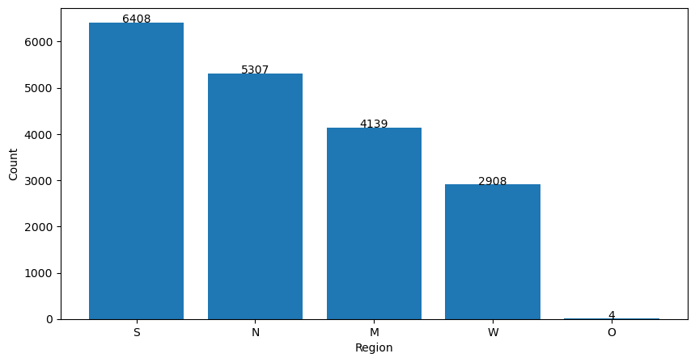

```python
# Python dictionary mapping two letter state abbreviations to their respective regions of the country (i.e. Midwest, North East, etc.)
# N - North East W - West M - Mid West S - South O - Other

states_to_region = {
        'AK': 'O',
        'AL': 'S',
        'AR': 'S',
        'AS': 'O',
        'AZ': 'W',
        'CA': 'W',
        'CO': 'W',
        'CT': 'N',
        'DC': 'N',
        'DE': 'N',
        'FL': 'S',
        'GA': 'S',
        'GU': 'O',
        'HI': 'O',
        'IA': 'M',
        'ID': 'W',
        'IL': 'M',
        'IN': 'M',
        'KS': 'M',
        'KY': 'S',
        'LA': 'S',
        'MA': 'N',
        'MD': 'N',
        'ME': 'N',
        'MI': 'W',
        'MN': 'M',
        'MO': 'M',
        'MP': 'O',
        'MS': 'S',
        'MT': 'W',
        'NA': 'O',
        'NC': 'S',
        'ND': 'M',
        'NE': 'W',
        'NH': 'N',
        'NJ': 'N',
        'NM': 'W',
        'NV': 'W',
        'NY': 'N',
        'OH': 'M',
        'OK': 'S',
        'OR': 'W',
        'PA': 'N',
        'PR': 'O',
        'RI': 'N',
        'SC': 'S',
        'SD': 'M',
        'TN': 'S',
        'TX': 'S',
        'UT': 'W',
        'VA': 'S',
        'VI': 'O',
        'VT': 'N',
        'WA': 'W',
        'WI': 'M',
        'WV': 'S',
        'WY': 'W'
}


df["res_region"] = df["res_state"].replace(states_to_region)
df['res_region'] = df['res_region'].astype('category')
value_counts = df["res_region"].value_counts()

fig, ax = plt.subplots(figsize=(10, 5))
ax.bar(value_counts.index, value_counts.values)
ax.set_xlabel("Region")
ax.set_ylabel("Count")

# add count values as annotations to each bar
for i, v in enumerate(value_counts.values):
    ax.text(i, v+1, str(v), ha='center', fontsize=10)

plt.show()
```

```
res_region
Index 	 Count
W 	 2908
N 	 5307
S 	 6408
M 	 4139
O 	 4
```

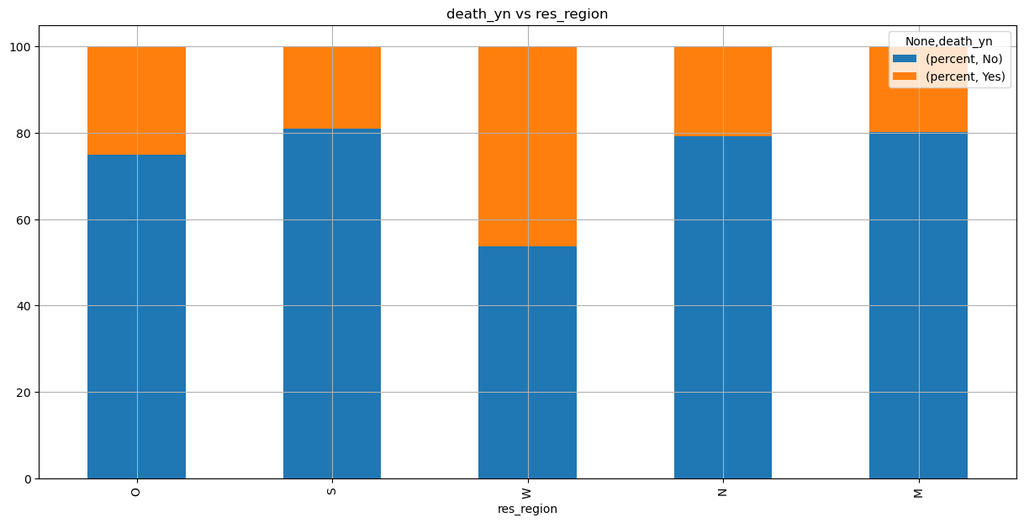

```python
#Using code from the module lab
underlying_conditions_yn = pd.unique(df["res_region"].ravel())


# add new column and set values to zero
df['percent'] = 0

#print header
print("res_region")
print("Index \t Count")

# for each underlying_conditions_yn category
for i in underlying_conditions_yn:

    count = df[df["res_region"] == i].count()['death_yn']
    count_percentage = (1 / count) * 100

    # print out index vs count
    print(i, "\t", count)

    index_list = df[df['res_region'] == i].index.tolist()
    for ind in index_list:
        df.loc[ind, 'percent'] = count_percentage

group = df[['percent','res_region','death_yn']].groupby(['res_region','death_yn']).sum()

my_plot = group.unstack().plot(kind='bar', stacked=True, title="death_yn vs res_region", figsize=(15,7), grid=True)
```

#### **New feature 2**

- The code creates a new column "elderly_yn" in the DataFrame to indicate whether a patient is 65 years old or older.
- The purpose of this code is to explore the distribution of elderly patients in the dataset and provide insights into the age distribution of COVID-19 patients.

```
CategoricalIndex([False, True], categories=[False, True], ordered=False, dtype='category')
```

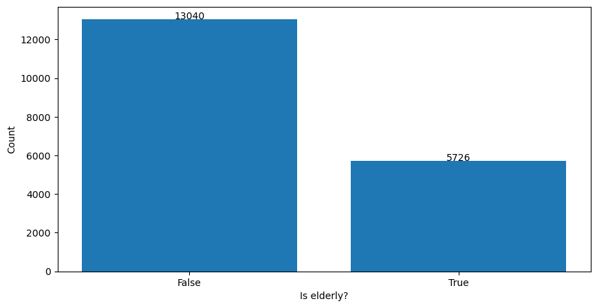

```python
df['elderly_yn'] = df['age_group'] == '65+ years'
df['elderly_yn'] = df['elderly_yn'].astype('category')
value_counts = df["elderly_yn"].value_counts()

print(value_counts.keys())
# df["elderly_yn"].value_counts().plot(kind='bar', figsize=(10,5))

fig, ax = plt.subplots(figsize=(10, 5))
ax.bar(value_counts.index.astype(str), value_counts.values)
ax.set_xlabel("Is elderly?")
ax.set_ylabel("Count")

# add count values as annotations to each bar
for i, v in enumerate(value_counts.values):
    ax.text(i, v+1, str(v), ha='center', fontsize=10)

plt.show()
```

```
elderly_yn
Index 	 Count
True 	 5726
False 	 13040
```

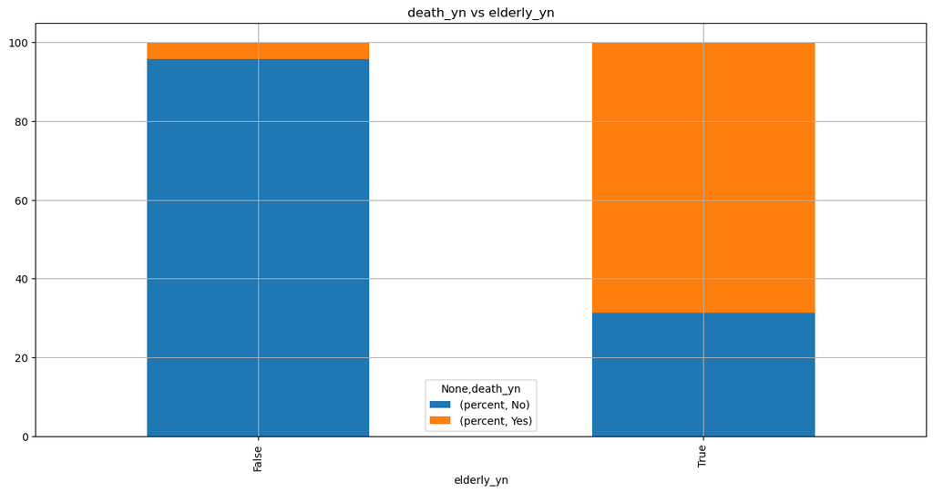

```python
#Using code from the module lab
underlying_conditions_yn = pd.unique(df["elderly_yn"].ravel())


# add new column and set values to zero
df['percent'] = 0

#print header
print("elderly_yn")
print("Index \t Count")

# for each underlying_conditions_yn category
for i in underlying_conditions_yn:

    count = df[df["elderly_yn"] == i].count()['death_yn']
    count_percentage = (1 / count) * 100

    # print out index vs count
    print(i, "\t", count)

    index_list = df[df['elderly_yn'] == i].index.tolist()
    for ind in index_list:
        df.loc[ind, 'percent'] = count_percentage

group = df[['percent','elderly_yn','death_yn']].groupby(['elderly_yn','death_yn']).sum()

my_plot = group.unstack().plot(kind='bar', stacked=True, title="death_yn vs elderly_yn", figsize=(15,7), grid=True)
```

#### **New feature 3**

- A new column 'time_diff' is created based on the difference between two time intervals in the dataframe.
- The column is then categorized as 'same', 'before', or 'after' based on the time difference, and the resulting value counts are printed.

```python
df['time_diff'] = df['case_positive_specimen_interval'] - df['case_onset_interval']
df['time_diff'] = np.where(df['time_diff'] == 0, 'same', np.where(df['time_diff'] > 0, 'after', 'before'))
df['time_diff'] = df['time_diff'].astype('category')
print(df['time_diff'].value_counts())
df[['case_positive_specimen_interval','case_onset_interval','time_diff']].head()
```

```
same      17289
after      1169
before      308
Name: time_diff, dtype: int64
```

|  | case_positive_specimen_interval | case_onset_interval | time_diff |
| --- | --- | --- | --- |
| 0 | 0 | 0 | same |
| 1 | 0 | 0 | same |
| 2 | 0 | 0 | same |
| 3 | 0 | 0 | same |
| 4 | 2 | 0 | after |